# ggplot - Statistical transformations

session 6a

Eviatar Guttman

Last updated: 27-06-2021

```r
library(tidyverse); library(patchwork)
```

# 1 visualising distributions

אופן הצגת התפלגות תלוי בשאלה האם משתנה הוא רציף או קטגורי (בדיד, דיסקרטי).  
משתנה הוא קטגורי אם הוא יכול לקבל מספר ערכים מצומצם. משתנים קטגוריים בד"כ שמורים כ- factor או character.

# 2 bar charts

## 2.1 intro

בכדי להציג התפלגויות נעבוד עם טבלת הנתונים `diamonds`

```r
head(diamonds)
```

```
## # A tibble: 6 x 10
##   carat cut       color clarity depth table price     x     y     z
##   <dbl> <ord>     <ord> <ord>   <dbl> <dbl> <int> <dbl> <dbl> <dbl>
## 1 0.23  Ideal     E     SI2      61.5    55   326  3.95  3.98  2.43
## 2 0.21  Premium   E     SI1      59.8    61   326  3.89  3.84  2.31
## 3 0.23  Good      E     VS1      56.9    65   327  4.05  4.07  2.31
## 4 0.290 Premium   I     VS2      62.4    58   334  4.2   4.23  2.63
## 5 0.31  Good      J     SI2      63.3    58   335  4.34  4.35  2.75
## 6 0.24  Very Good J     VVS2     62.8    57   336  3.94  3.96  2.48
```

הטבלה כוללת נתוני מחירים ומאפיינים של כ-54 אלף יהלומים. ארבעה פרמטרים של איכות: carat, cut, colur, clarity, ו-5 אמות מידה פיסיות, x, y ,z depth, table:

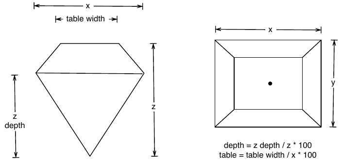

בכדי לבחון התפלגות של משתנה קטגורי נשתמש ב-bar chart:

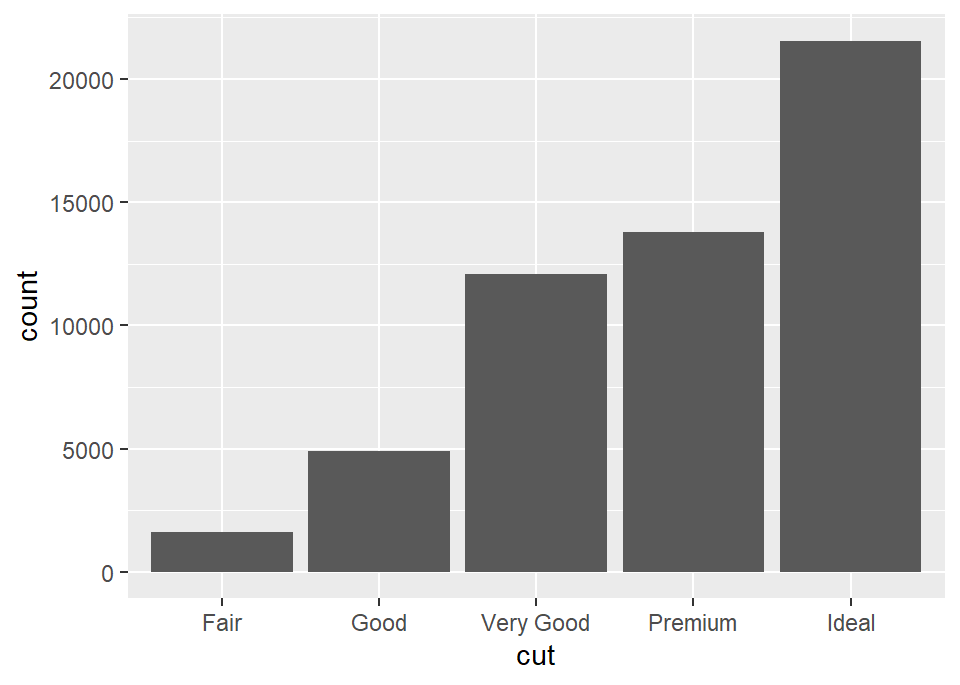

```r
ggplot(data = diamonds) + geom_bar(mapping = aes(x = cut))
```

יש שני סוגים של גרפים הנקראים בד"כ barplot. הגרף שהצגנו מקבל data שלא עבר סכימה, וכל תצפית תורמת יחידה אחת של גובה לכל bar. הסוג האחר של barplot משמש לנתונים שעברו סכימה מראש, וגובה העמודה מייצג את הערך בנתונים.  
למשל:

```r
drugs <- data.frame(
  drug = c("a", "b", "c"),
  effect = c(4.2, 9.7, 6.1))
```

במקרה זה אולי כדאי להשתמש ב-`geom_point`. זה צורך פחות מקום להצגת הנתונים וציר ה-y לא צריך להכיל את הערך 0.

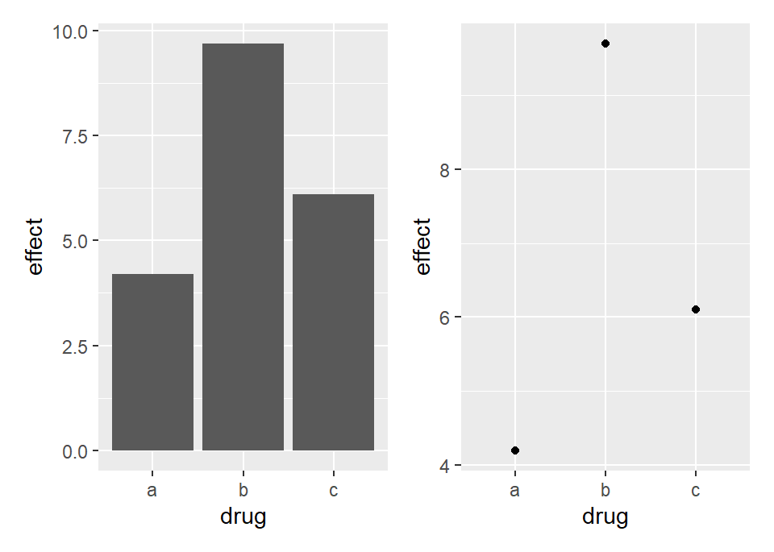

```r
p1 <- ggplot(drugs, aes(drug, effect)) + geom_bar(stat = "identity")
p2 <- ggplot(drugs, aes(drug, effect)) + geom_point()
p1 + p2
```

נשוב ל- `diamonds`.  
המשתנה `count` הוא לא חלק מבסיס הנתונים.  
Bar charts, histograms and frequency polygons מחלקים את הנתונים ל-bins ואז מציגים בגרף את מספר התצפיות שיש בכל bin.

Smoothers כמו שהשתמשנו כאשר עשינו גרף עם `geom_smooth` אומדים מודל על הנתונים ומציגים את התחזית של המודל.

Boxplots מחשבים סטטיסטיים המסכמים את ההתפלות ואז מציגים זאת בקופסה מעוצבת.

האלגוריתם המשמש לחישוב ערכים חדשים לגרף נקרא **stat** , קיצור ל-statistical transformation.

המשתנה שהציג את התפלגות ה-`cut` ב-`diamonds` הוא:

```r
diamonds %>% count(cut)
```

```
## # A tibble: 5 x 2
##   cut           n
##   <ord>     <int>
## 1 Fair       1610
## 2 Good       4906
## 3 Very Good 12082
## 4 Premium   13791
## 5 Ideal     21551
```

לכן, ניתן להציג את אותו הגרף באמצעות הקוד:

```r
p1 <- diamonds %>% count(cut) %>%
  ggplot() + geom_bar(aes(cut, n), stat = 'identity')
```

ניתן לראות באמצעות איזה **stat** ה-`geom` משתמש אם בודקים את ארגומנט ברירת המחדל של ה-`geom` באמצעות `?geom_bar`. בדיקה של ה-help של הפונקציה מראה שה-`stat` הוא `count`. ב-help של הפונקציה אפשר לבדוק גם את ה“משתנים המחושבים” שה-geom יוצר.  
אפשרות נוספת היא להשתמש ב-`ggplot_built`.

```r
p1_data <-ggplot_build(p1)
p1_data[["data"]]
## [[1]]
##   x     y PANEL group flipped_aes ymin  ymax xmin xmax colour   fill size
## 1 1  1610     1     1       FALSE    0  1610 0.55 1.45     NA grey35  0.5
## 2 2  4906     1     2       FALSE    0  4906 1.55 2.45     NA grey35  0.5
## 3 3 12082     1     3       FALSE    0 12082 2.55 3.45     NA grey35  0.5
## 4 4 13791     1     4       FALSE    0 13791 3.55 4.45     NA grey35  0.5
## 5 5 21551     1     5       FALSE    0 21551 4.55 5.45     NA grey35  0.5
##   linetype alpha
## 1        1    NA
## 2        1    NA
## 3        1    NA
## 4        1    NA
## 5        1    NA
```

`ggplot_built` זו פונקציה שיוצרת אובייקט המכיל את כל המידע ששימש לבניית הגרף.  
למעשה, ניתן להציג את אותו הגרף תוך הוספת layer באמצעות פונקציה בשם `stat_count`, אשר ברירת המחדל בארגומנט ה-geom שלה הוא `bar`.  
לכל `geom` יש סטטיסטי ברירת מחדל, ולכל `stat` יש `geom` ברירת מחדל.

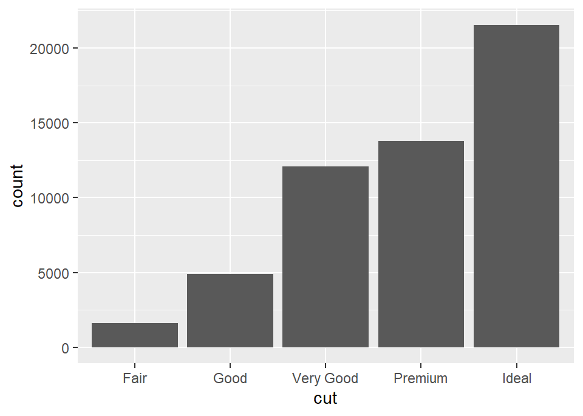

```r
ggplot(diamonds, aes(cut)) + stat_count()
```

סיבות לכך שנרצה להשתמש ב-stat באופן מפורש הן: שאולי נרצה לדרוס את ברירת המחדל ולבחור סטטיסטי אחר, או שאולי נרצה להסב את תשומת הלב לטרנספורמציה הסטטיסטית שהגרף עושה:

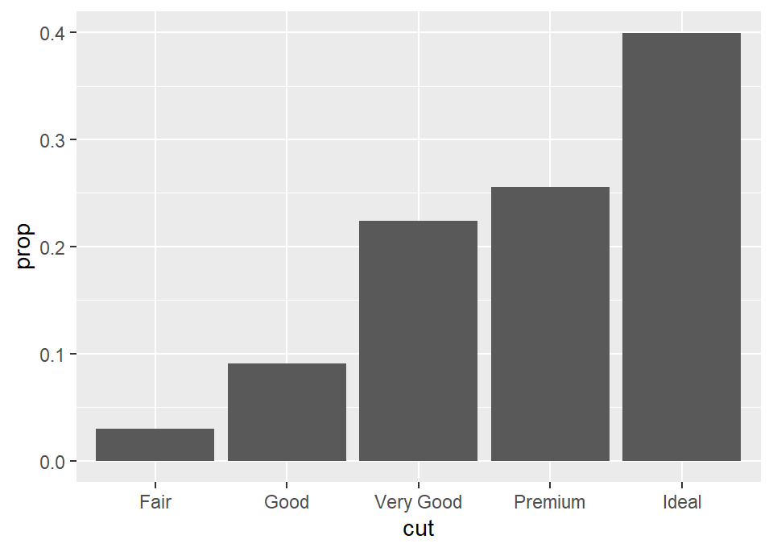

```r
ggplot(data = diamonds) +
  geom_bar(mapping = aes(x = cut, y = stat(prop), group = 1))
```

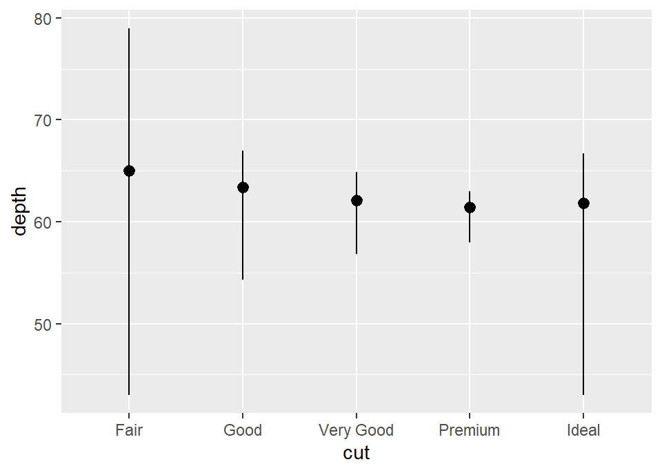

```r
ggplot(data = diamonds) +
  stat_summary(
    mapping = aes(x = cut, y = depth),
    fun.min = min,
    fun.max = max,
    fun = median
  )
```

## 2.2 position adjustments

`scale_color` צובע נקודות וקווים. `scale_fill` צובע שטחים.

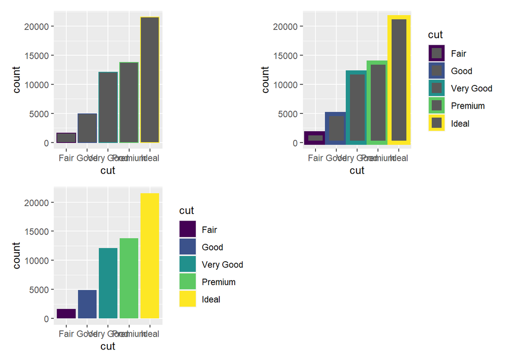

```r
p1 <- ggplot(data = diamonds) +
  geom_bar(mapping = aes(x = cut, colour = cut)) +
  guides(color = "none")

p2 <- ggplot(data = diamonds) +
  geom_bar(mapping = aes(x = cut, colour = cut), size = 2)

# better use fill
p3 <- ggplot(data = diamonds) +
  geom_bar(mapping = aes(x = cut, fill = cut))

p1 + p2 + p3  + plot_layout(ncol = 2)
```

אפשר לצבוע באמצעות משתנה אחר מטבלת הנתונים.

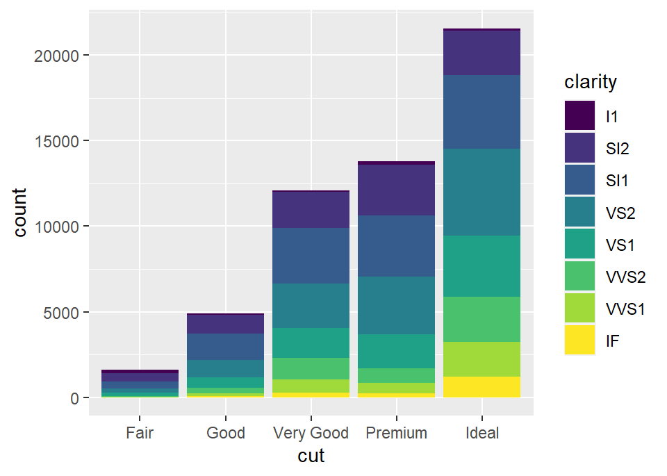

```r
ggplot(data = diamonds) +
  geom_bar(mapping = aes(x = cut, fill = clarity))
```

יש שלוש אפשרויות למיקום ה-bars בגרף: “identity”, “dodge”, and “fill”.  
“ideneity” לא ממש מועיל בדוגמא זו.

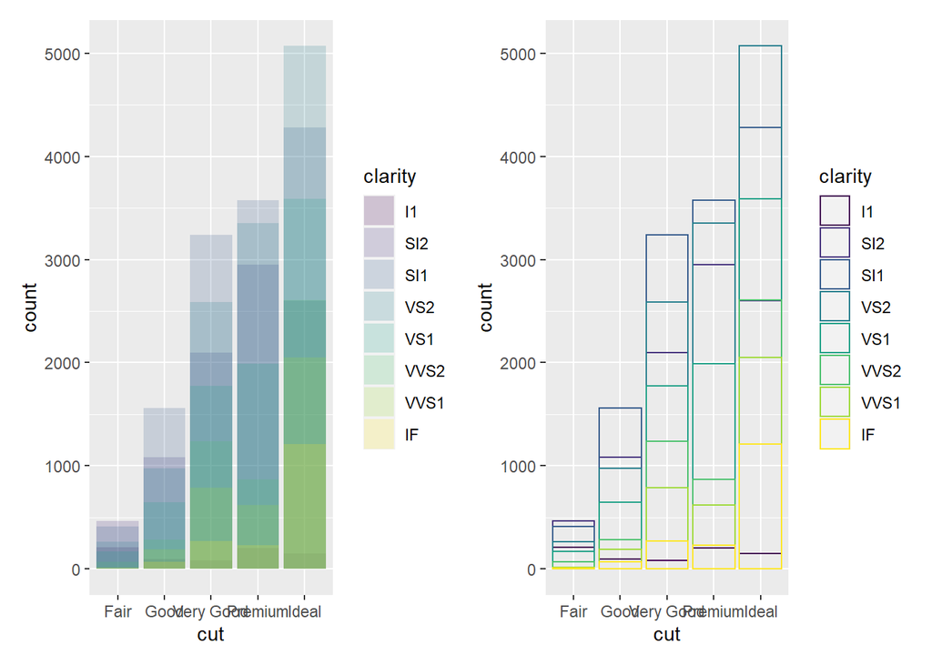

```r
p1 <- ggplot(data = diamonds, mapping = aes(x = cut, fill = clarity)) +
  geom_bar(alpha = 1/5, position = "identity")
p2 <- ggplot(data = diamonds, mapping = aes(x = cut, colour = clarity)) +
  geom_bar(fill = NA, position = "identity")
p1 + p2
```

`position = "fill"` עורם את הערכים זה על זה והופך את כל ה bars להיות באותו גובה. זה מועיל כאשר רוצים להשוות פרופורציות בין קבוצות.

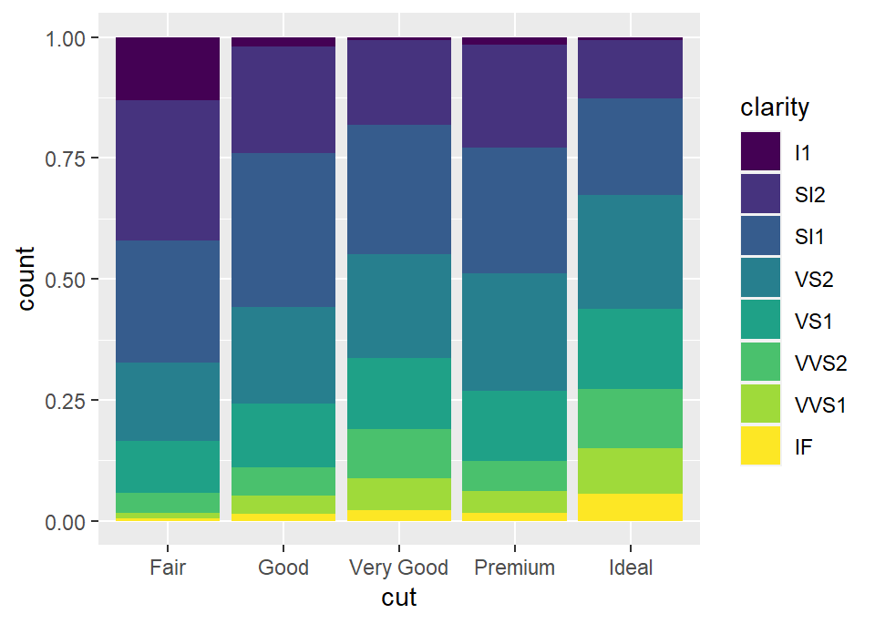

```r
ggplot(data = diamonds) +
  geom_bar(mapping = aes(x = cut, fill = clarity), position = "fill")
```

`position = "dodge"` ממקם רכיבים חופפים זה ליד זה. זה מאפשר להשוות בין ערכים שונים.

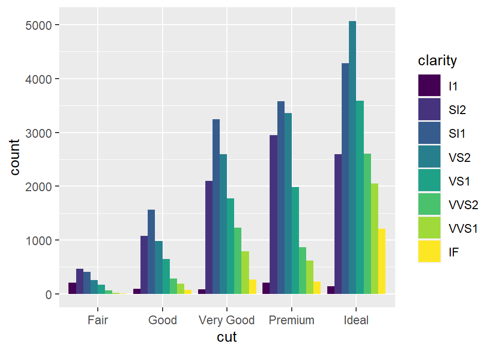

```r
ggplot(data = diamonds) +
  geom_bar(mapping = aes(x = cut, fill = clarity), position = "dodge")
```

# 3 histograms

## 3.1 intro

משתנה הוא רציף אם הוא יכול לקבל ערך כלשהו מקבוצת ערכים אינסופית וסדורה.  
כדי לבחון התפלגות של משתנה רציף נשתמש בהיסטוגרמה.

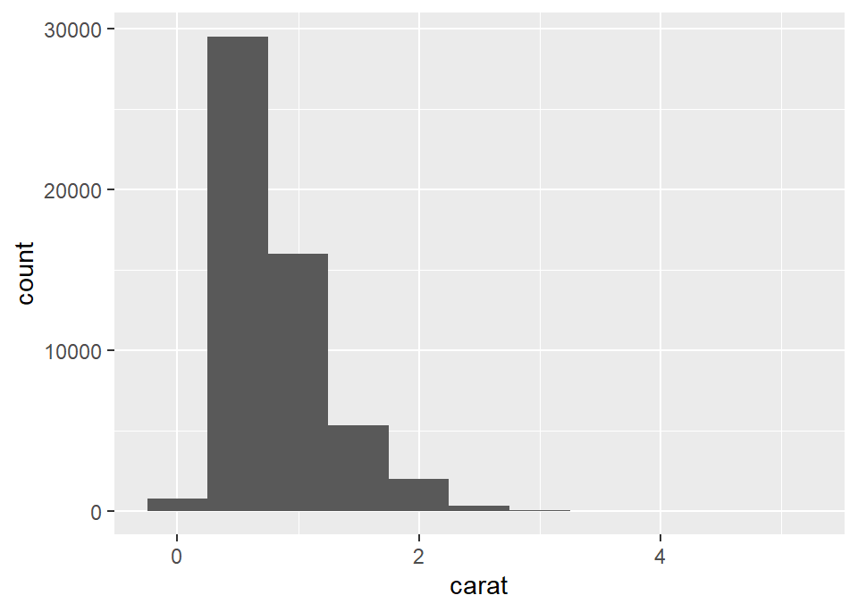

```r
ggplot(data = diamonds) +
  geom_histogram(mapping = aes(x = carat), binwidth = 0.5)
```

אפשר לחשב את הנתונים הללו ידנית תוך שילוב של `dplyr::count` ו- `ggplot2::cut_width`:

```r
(his_count <- diamonds %>% count(cut_width(carat, 0.5)))
```

```
## # A tibble: 11 x 2
##    `cut_width(carat, 0.5)`     n
##    <fct>                   <int>
##  1 [-0.25,0.25]              785
##  2 (0.25,0.75]             29498
##  3 (0.75,1.25]             15977
##  4 (1.25,1.75]              5313
##  5 (1.75,2.25]              2002
##  6 (2.25,2.75]               322
##  7 (2.75,3.25]                32
##  8 (3.25,3.75]                 5
##  9 (3.75,4.25]                 4
## 10 (4.25,4.75]                 1
## 11 (4.75,5.25]                 1
```

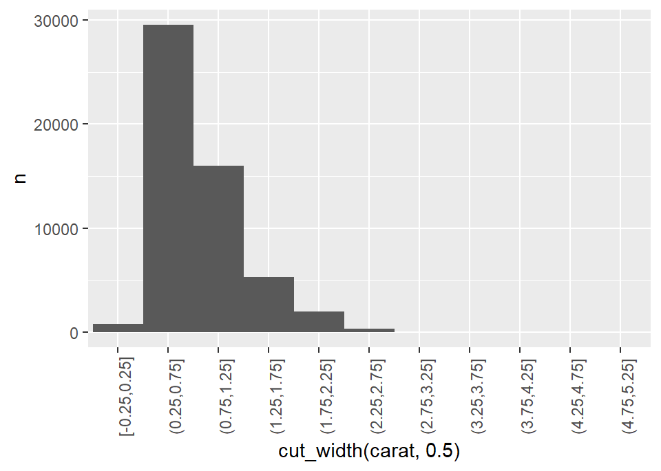

```r
ggplot(his_count, aes(x = `cut_width(carat, 0.5)`, y = n)) + geom_col(width = 1) +
  theme(axis.text.x  = element_text(angle = 90))
```

היסטוגרמה מחלקת את ציר x ל-bins בגדלים שווים ואז משתמשת בגובה ה-bar כדי להציג את מספר התצפיות שנפלו בתוך כל bin.

כדאי להתנסות במספרי bins שונים, משום ש-bins ברוחב שונים יכולים לגלות תבניות שונות בנתונים

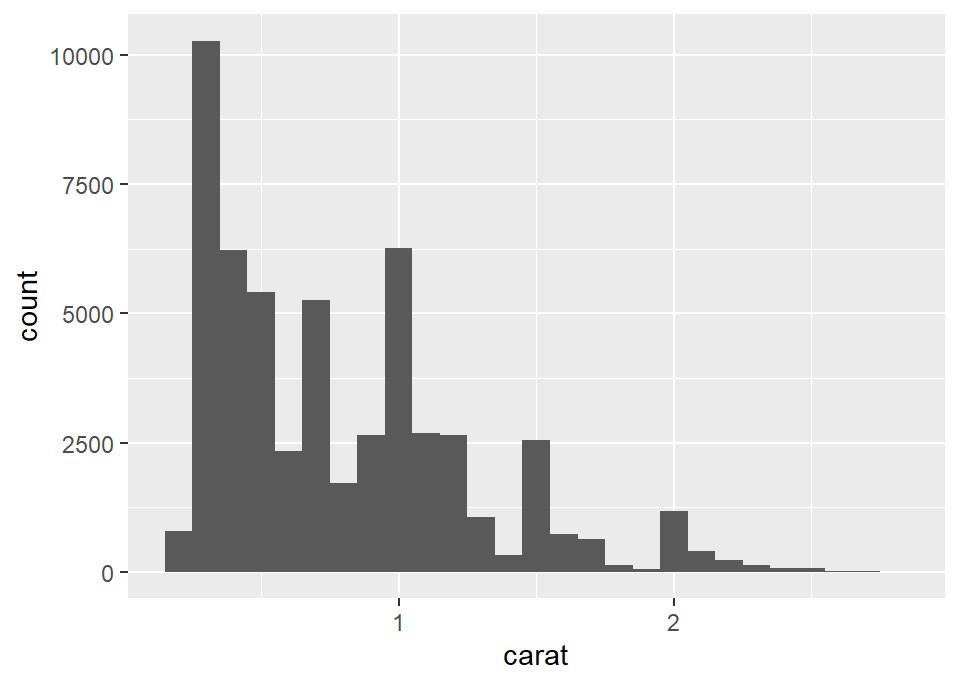

```r
smaller <- diamonds %>%
  filter(carat < 3)

ggplot(data = smaller, mapping = aes(x = carat)) +
  geom_histogram(binwidth = 0.1)
```

כאשר מציגים את הנתונים, לא לשכוח לכלול מידע על פרמטרים חשובים כגון רוחב ה-bin ב-caption של הגרף.

`geom_freqpoly` מבצע את אותם חישובים כמו `geom_histogram` אך מציג את ה counts באמצעות קווים במקום bars. יותר קל לראות קווים חופפים מאשר bars חופפים.

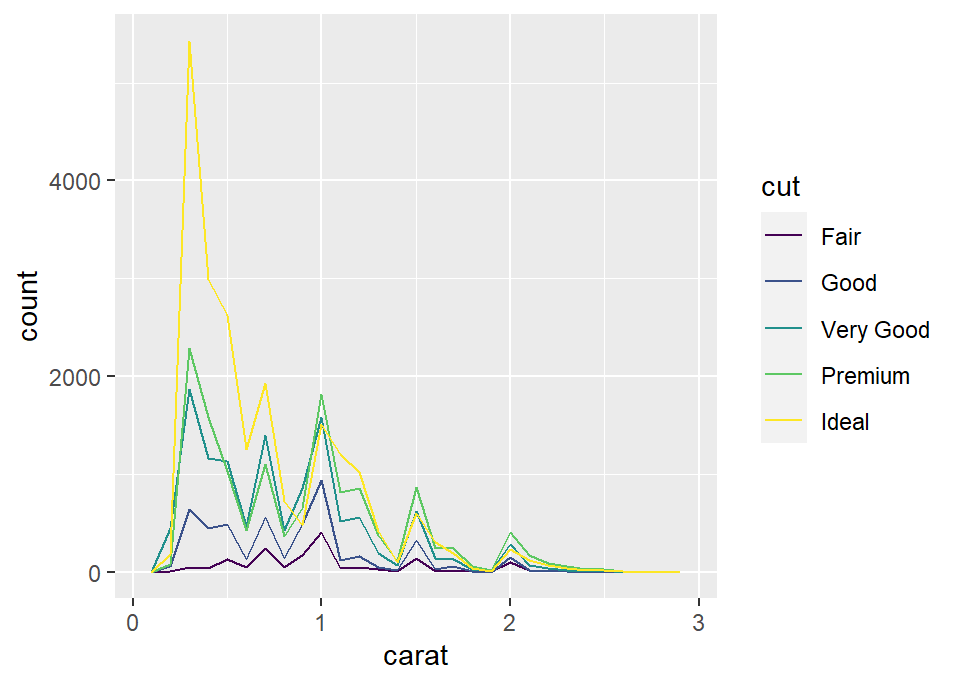

```r
ggplot(data = smaller, mapping = aes(x = carat, colour = cut)) +
  geom_freqpoly(binwidth = 0.1)
```

האינדיקציה לקיומן של תצפיות חריגות (outliers) היא כאשר גבולות הגרף רחבים.

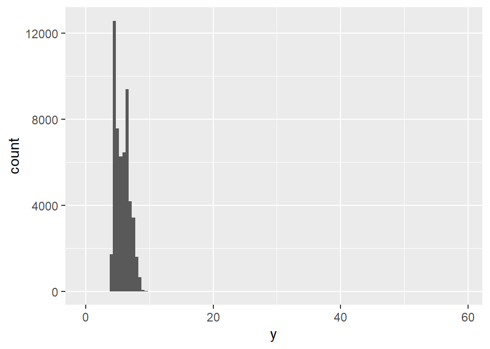

```r
ggplot(diamonds) +
  geom_histogram(mapping = aes(x = y), binwidth = 0.5)
```

נבצע זום אין באמצעות `coord_cartesian`:

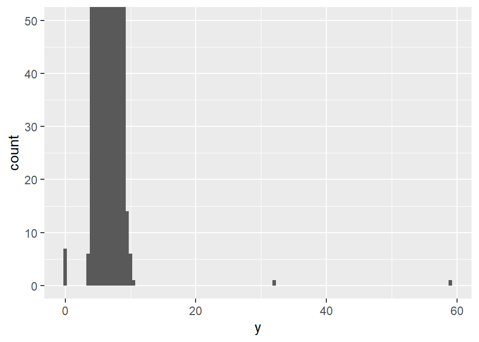

```r
ggplot(diamonds) +
  geom_histogram(mapping = aes(x = y), binwidth = 0.5) +
  coord_cartesian(ylim = c(0, 50))
```

נזכור שהפונקציות `xlim`, `ylim`, `lims` עובדות אחרת, הן משמיטות תצפיות מחוץ לגבול.

## 3.2 missing values

איך נתייחס לערכים חסרים?  
אפשר להשמיט את כל השורה בה יש ערכים לא שגרתיים.

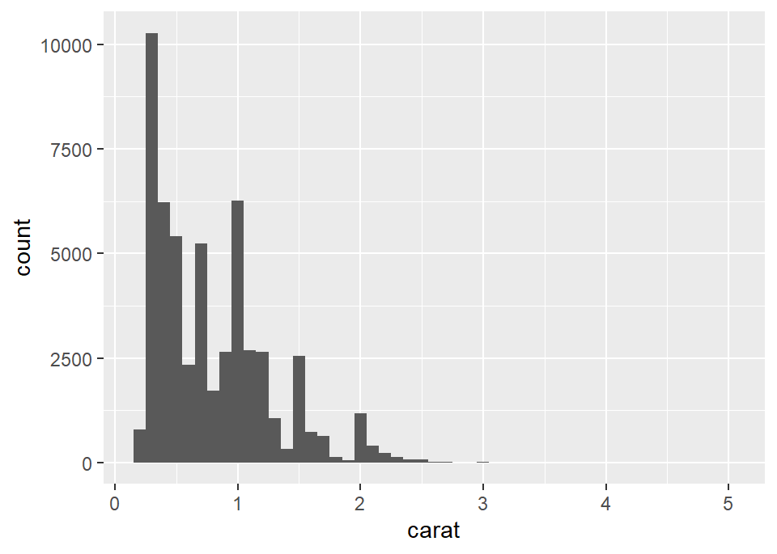

```r
diamonds2 <- diamonds %>%
  filter(between(y, 3, 20))

ggplot(data = diamonds2) +
  geom_histogram(mapping = aes(x = carat), binwidth = 0.1)
```

רק בגלל שערך אחד בתצפיות הוא לא סביר, לא אומר שצריך לזרוק את כל התצפית. כאשר בסיס הנתונים באיכות נמוכה, השמטת תצפיות כל פעם שאחת המדידות לא סבירה תביא לכך שבסוף יישארו מעט נתונים.  
כדאי להחליף את הערכים הלא סבירים בערכים חסרים.

```r
diamonds2 <- diamonds %>%
  mutate(y = if_else(y < 3 | y > 20, NA_real_, y))
```

ל- `if_else` יש שלושה ארגומנטים אשר על המשתמש להזין . הראשון הוא תנאי לוגי , השני הוא הוא הפעולה שתבוצע עם התנאי הוא `TRUE` והשלישי הוא הפעולה במקרה שהוא `FALSE`. (יש גם ארגומנט רביעי המציין מה לעשות כאשר הוזן ערך `NA` לתוך התנאי הלוגי).  
אם יש צורך ביותר משתי חלופות של תנאים, אפשר להשתמש ב-`case_when`.

יש לשים לב לערכים חסרים המושמטים מהתרשים. אמנם ggplot לא מציגה אותם בגרף אך היא כן מדפיסה message או warning בקונסולה המציין שהיו ערכים שהוסרו.

```
## Warning: Removed 9 rows containing missing values (geom_point).
```

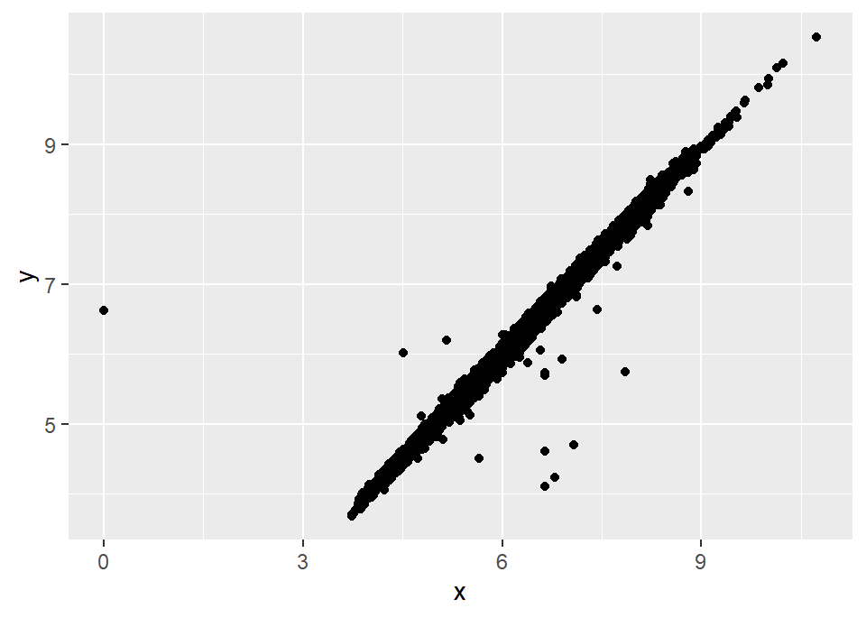

```r
ggplot(data = diamonds2, mapping = aes(x = x, y = y)) +
  geom_point()
```

אנו רוצים לדעת מה הופך תצפיות עם ערכים חסרים לשונות. לדוגמא ב-filghts, ערכים חסרים ב-`dep_time` מייצגים טיסות שבוטלו.  
אולי נרצה להשוות בין זמנים מתוכננים של טיסות שיצאו לבין אלה שלא יצאו.

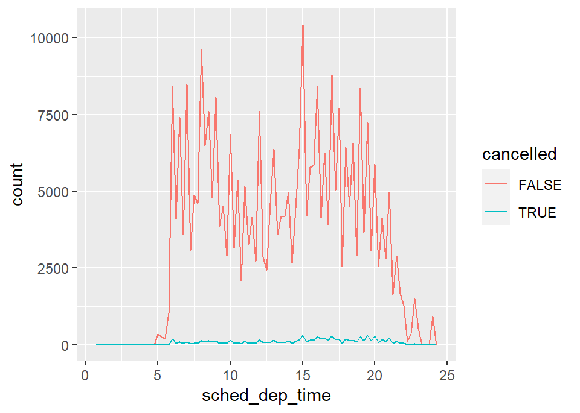

```r
nycflights13::flights %>%
  mutate(
    cancelled = is.na(dep_time),
    sched_hour = sched_dep_time %/% 100,
    sched_min = sched_dep_time %% 100,
    sched_dep_time = sched_hour + sched_min / 60
  ) %>%
  ggplot(mapping = aes(sched_dep_time)) +
    geom_freqpoly(mapping = aes(colour = cancelled), binwidth = 1/4)
```

## 3.3 densityes

היסטוגרמות (וגם פוליגונים המשמשים כהיסטוגרמה דו-ממדית) עושות טרנספורמציה סטטיסטית שנקראת `stat = bin`. הסטטיסטי הזה יוצר שני משתנים: count ו- density .  
ברירת המחדל היא ש- count ממופה לציר ה-y, משום שהוא ניתן לפרשנות בקלות.  
Density זה ה-count מחולק בסך כל ה-counts מוכפל ברוחב ה-bin. כך, שטח הגרף מנורמל ל-1.  
Density טוב לשימוש כאשר רוצים להשוות בין צורה של התפלגות מבלי להתייחס למספר התצפיות הכללי.  
`geom_density` יוצר מעין התפלגות נורמלית בכל נקודה וסוכם את העקומות. בשל כך, קשה יותר לקשר בינו ובין הנתונים המקוריים.  
נשתמש ב-density plot כאשר אנו יודעים שההתפלגות חלקה, רציפה ולא חסומה.

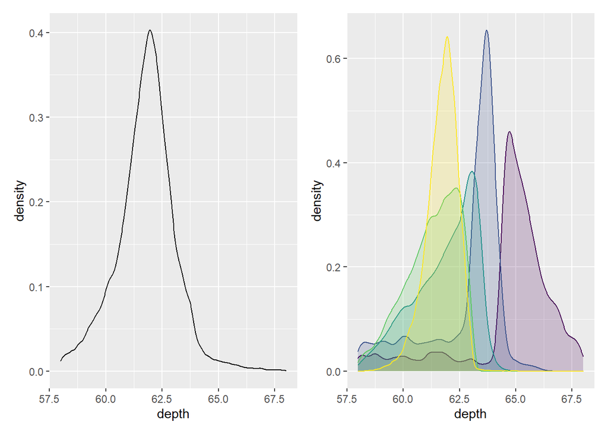

```r
p1 <- ggplot(diamonds, aes(depth)) +
  geom_density(na.rm = TRUE) +
  xlim(58, 68) +
  theme(legend.position = "none")

p2 <- ggplot(diamonds, aes(depth, fill = cut, colour = cut)) +
  geom_density(alpha = 0.2, na.rm = TRUE) +
  xlim(58, 68) +
  theme(legend.position = "none")

p1 + p2
```

משום שהשטח של כל עקומה מנורמל ל-1, אנו מאבדים קשר עם הגודל היחסי של כל קבוצה.

# 4 box plots

לעיתים רוצים להשוות מספר רב של התפלגויות. במקרים אלה אפשר לבחור בשיטות המתפשרות באיכות בכדי להציג כמות.  
Box plot מראה חמישה סטטיסטיים ותצפיות חריגות.

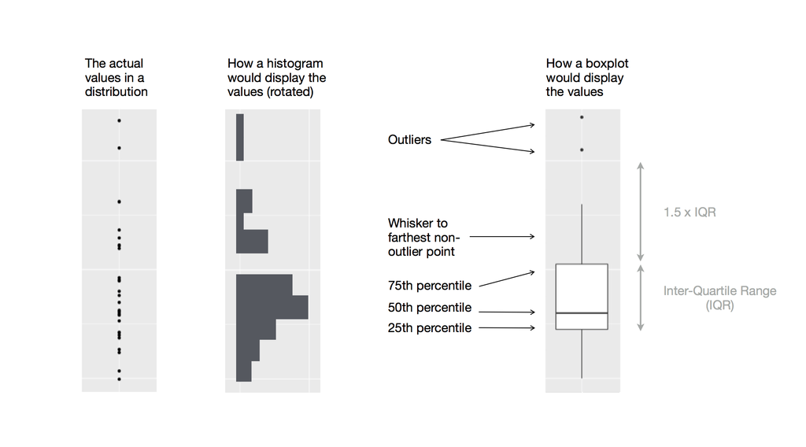

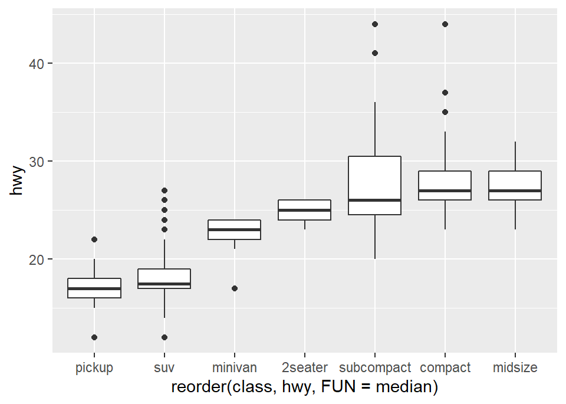

```r
ggplot(data = mpg) +
  geom_boxplot(mapping = aes(x = reorder(class, hwy, FUN = median), y = hwy))
```

Box plot הוא פתרון טוב להציג משתנה רציף מחולק לקטגוריות של משתנה בדיד.  
כאשר רוצים להציג שני משתנים רציפים, אחת החלופות היא scatter plot.

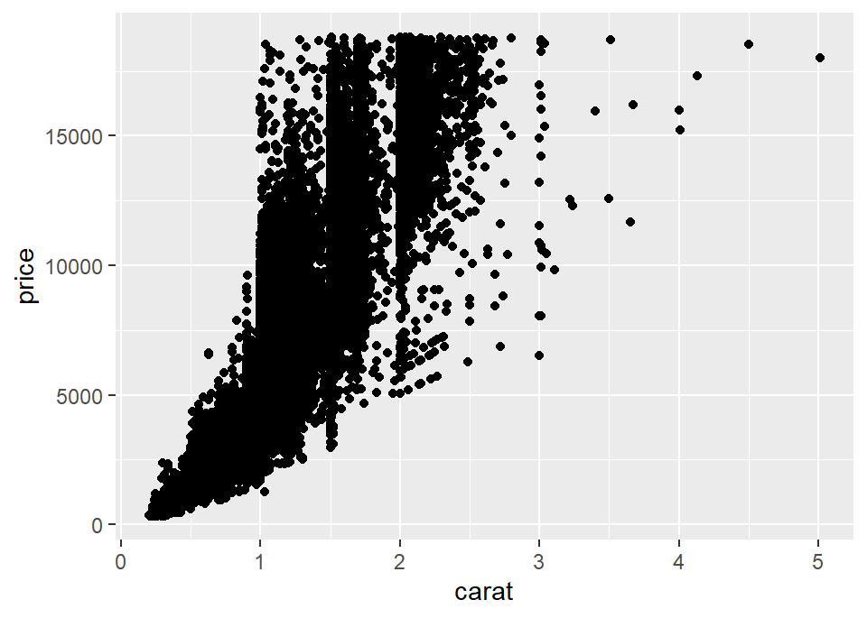

```r
ggplot(diamonds, aes(carat, price)) + geom_point()
```

Scatter plot מועיל פחות כאשר גודל הנתונים עולה.  
אפשר לשחק עם פרמטר ה-alpha בכדי להציג יותר נתונים על הגרף

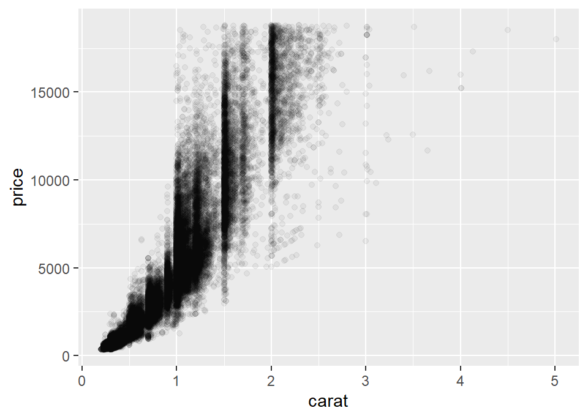

```r
ggplot(diamonds, aes(carat, price)) + geom_point(alpha = 1/20)
```

פתרון נוסף הוא להשתמש ב- `geom_bin2d` כדי ליצור bins בצורת ריבועים.  
אפשר להשתמש ב -`geom_hex` כדי ליצור bins בצורת משושים. וכן, ישנם פתרונות נוספים בהרחבות ל-ggplot.

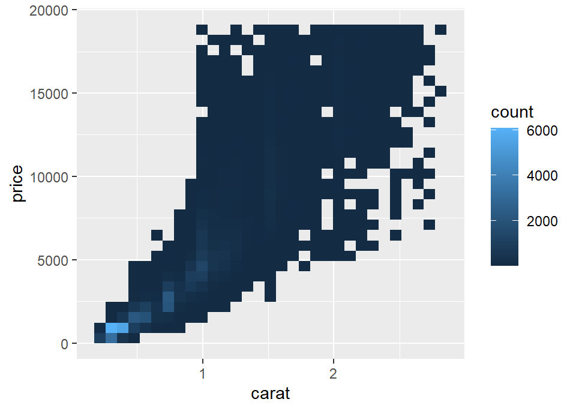

```r
diamonds %>% filter(carat < 3) %>%
  ggplot(aes(carat, price)) + geom_bin2d()
```

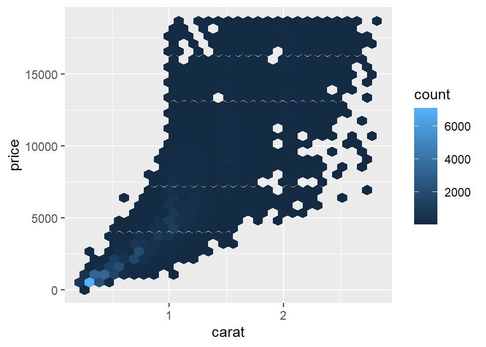

```r
library(hexbin)
diamonds %>% filter(carat < 3) %>%
  ggplot(aes(carat, price)) + geom_hex()
```

חלופה נוספת היא לעשות bining למשתנה רציף כאילו היה משתנה קטגורי

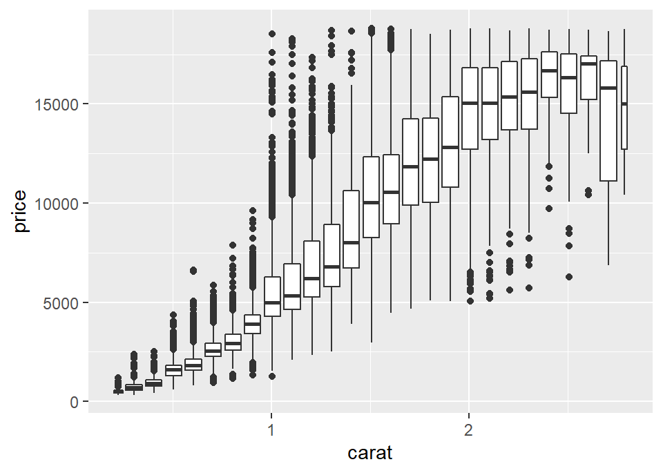

```r
diamonds %>% filter(carat < 3) %>%
  ggplot(aes(carat, price)) + geom_boxplot(aes(group = cut_width(carat, 0.1)))
```

`cut_width` מחלק את x ל-bins

```r
diamonds %>% filter(carat < 3) %>% mutate(cut_carat = cut_width(carat, 0.1))
```

```
## # A tibble: 53,900 x 11
##    carat cut       color clarity depth table price     x     y     z cut_carat
##    <dbl> <ord>     <ord> <ord>   <dbl> <dbl> <int> <dbl> <dbl> <dbl> <fct>
##  1 0.23  Ideal     E     SI2      61.5    55   326  3.95  3.98  2.43 [0.15,0.25]
##  2 0.21  Premium   E     SI1      59.8    61   326  3.89  3.84  2.31 [0.15,0.25]
##  3 0.23  Good      E     VS1      56.9    65   327  4.05  4.07  2.31 [0.15,0.25]
##  4 0.290 Premium   I     VS2      62.4    58   334  4.2   4.23  2.63 (0.25,0.35]
##  5 0.31  Good      J     SI2      63.3    58   335  4.34  4.35  2.75 (0.25,0.35]
##  6 0.24  Very Good J     VVS2     62.8    57   336  3.94  3.96  2.48 [0.15,0.25]
##  7 0.24  Very Good I     VVS1     62.3    57   336  3.95  3.98  2.47 [0.15,0.25]
##  8 0.26  Very Good H     SI1      61.9    55   337  4.07  4.11  2.53 (0.25,0.35]
##  9 0.22  Fair      E     VS2      65.1    61   337  3.87  3.78  2.49 [0.15,0.25]
## 10 0.23  Very Good H     VS1      59.4    61   338  4     4.05  2.39 [0.15,0.25]
## # ... with 53,890 more rows
```

החיסרון ב-box plot הוא שזה אותו גרף עבור קבוצות תצפיות בגדלים שונים. אפשר להשתמש `varwidth` כדי לעשות את גודל ה-box פרופורציוני לשורש הריבועי של מספר התצפיות:

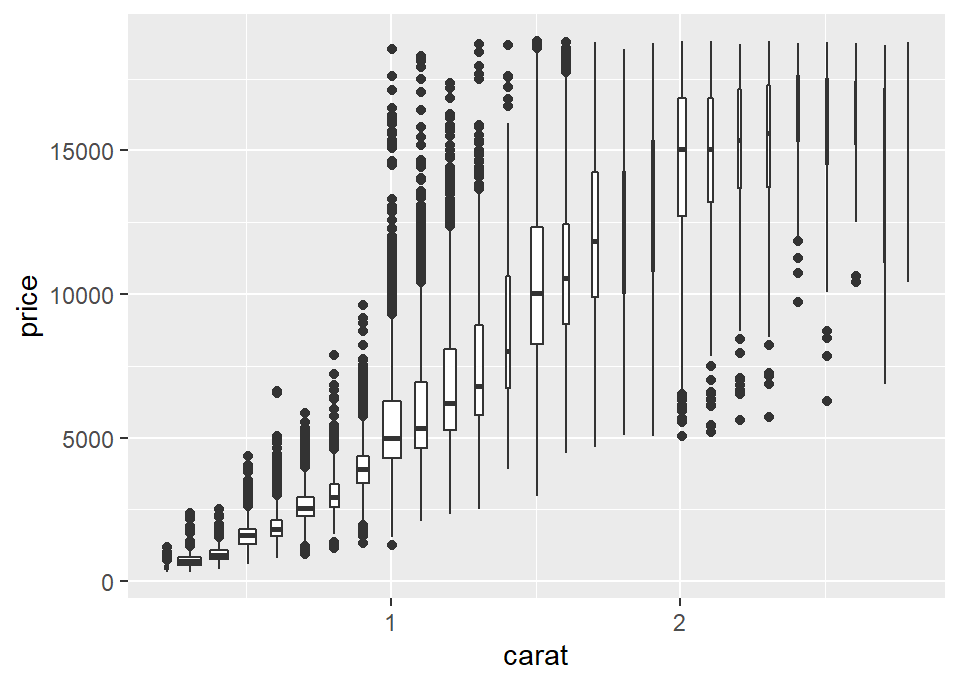

```r
diamonds %>% filter(carat < 3) %>%
  ggplot(aes(carat, price)) + geom_boxplot(aes(group = cut_width(carat, 0.1)), varwidth = T)
```

אפשר להשתמש ב-`cut_number` כדי לחלק את הנתונים לקבוצות שוות גודל.

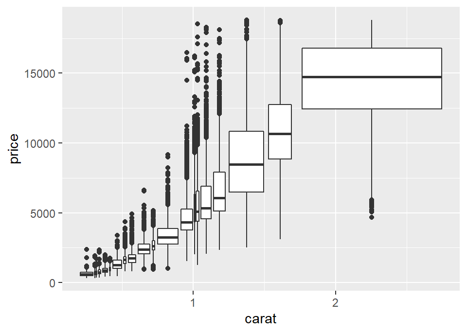

```r
diamonds %>% filter(carat < 3) %>%
  ggplot(aes(carat, price)) + geom_boxplot(aes(group = cut_number(carat, 20)))
```